# Introduction

#### Decision Tree with PCA

We test the simple decision tree on a different number of components and getting the results

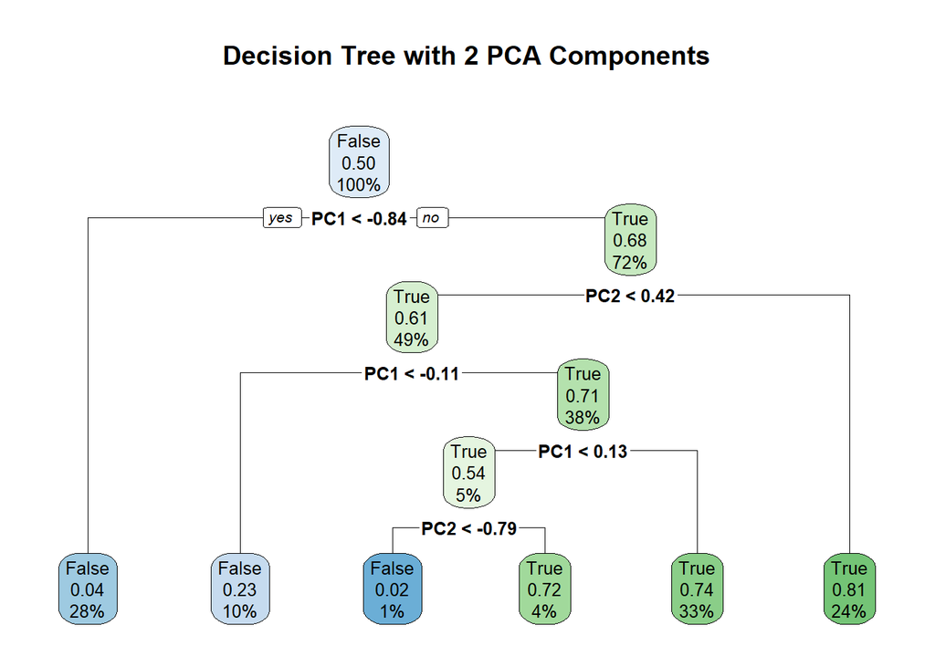

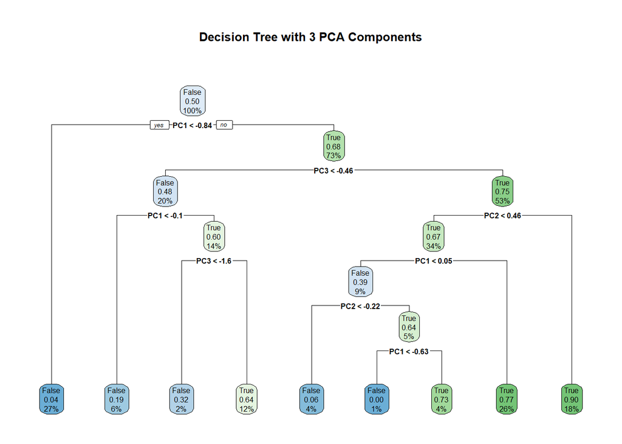

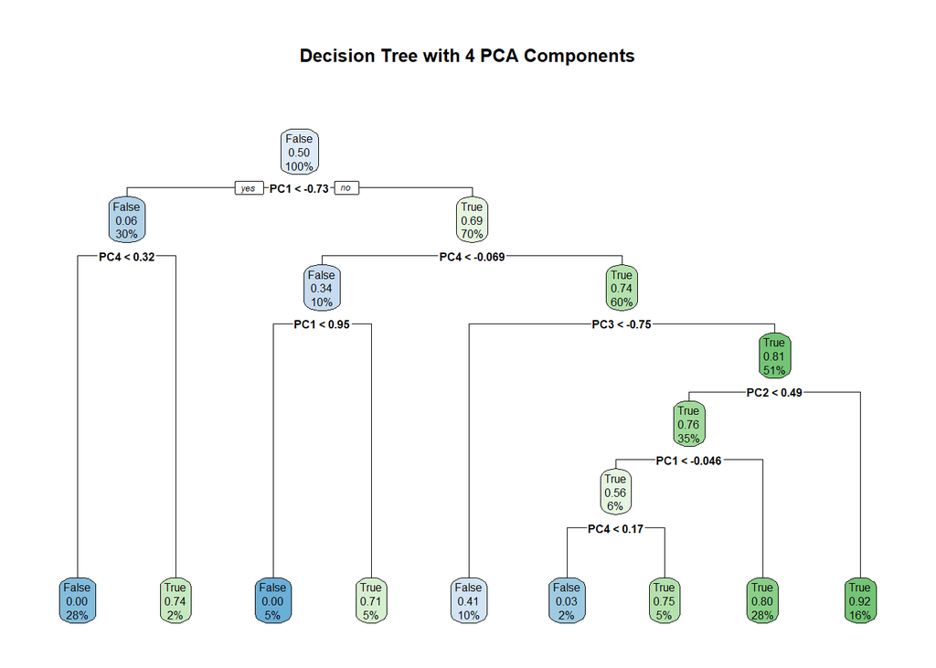

```r
set.seed(123)
# Function to perform Decision Tree analysis with PCA components and plot the tree
perform_decision_tree_analysis <- function(num_components) {
  pca_data <- pca_result$x[, 1:num_components]
  pca_df <- as.data.frame(pca_data)
  pca_df$hazardous <- data$hazardous

  splitIndex <- createDataPartition(pca_df$hazardous, p = 0.8, list = FALSE)
  train_data_pca <- pca_df[splitIndex,]
  test_data_pca <- pca_df[-splitIndex,]

  formula <- as.formula(paste("hazardous ~", paste(colnames(pca_data), collapse = " + ")))
  model_pca <- rpart(formula, data = train_data_pca, method = "class")

  # Plotting the decision tree
  plot_title <- paste("Decision Tree with", num_components, "PCA Components")
  rpart.plot(model_pca, main = plot_title)

  predictions_pca <- predict(model_pca, newdata = test_data_pca, type = "class")
  cm_pca <- table(test_data_pca$hazardous, predictions_pca)

  return(data.frame(components = num_components,
                    accuracy = mean(predictions_pca == test_data_pca$hazardous),
                    balanced_accuracy = cvms::confusion_matrix(targets = test_data_pca$hazardous, predictions = predictions_pca)$`Balanced Accuracy`,
                    sensitivity = cvms::confusion_matrix(targets = test_data_pca$hazardous, predictions = predictions_pca)$Sensitivity,
                    specificity = cvms::confusion_matrix(targets = test_data_pca$hazardous, predictions = predictions_pca)$Specificity,
                    F1 = cvms::confusion_matrix(targets = test_data_pca$hazardous, predictions = predictions_pca)$F1))
}

# Perform and plot Decision Tree analysis for different PCA components
all_dt_results <- do.call("rbind", lapply(2:4, perform_decision_tree_analysis))
```

```r
# Output the combined results
print(all_dt_results)
```

```
##   components  accuracy balanced_accuracy sensitivity specificity        F1
## 1          2 0.8283410         0.8283410   0.9078341   0.7488479 0.8409819
## 2          3 0.8387097         0.8387097   0.9447005   0.7327189 0.8541667
## 3          4 0.8237327         0.8237327   0.9078341   0.7396313 0.8374070
```

When using PCA, there’s a noticeable drop in accuracy and sensitivity compared to the original model without PCA. This could be due to the loss of some information during the dimensionality reduction process. PCA simplifies the data by focusing on components that explain the most variance, which might sometimes exclude subtler but still important information captured by the original features.

## Support Vector Machines

### Prepare and split data

Just splitting the datasetinto training and testing sets with an 80-20 split

```r
set.seed(123)
data$hazardous <- factor(data$hazardous, levels = c("False", "True"))

# for reproducibility
splitIndex <- createDataPartition(data$hazardous, p = .8, list = FALSE)
train_data <- data[splitIndex,]
test_data <- data[-splitIndex,]
```

### Fitting the Model

The SVM model is fitted using different kernels: linear, polynomial, radial, and sigmoid.

```r
# Initialize results dataframe
results <- data.frame()
kernels <- c("linear", "polynomial", "radial", "sigmoid")
roc_data <- data.frame()

# Convert feature names to a formula string
formula_string <- paste("hazardous ~", paste(feature_names, collapse = " + "))

# Convert the string to a formula
svm_formula <- as.formula(formula_string)



# SVM analysis and ROC data collection
for (kernel in kernels) {
  # Train the model with probability estimation using the formula
  model <- svm(svm_formula,
               data = train_data,
               type = 'C-classification',
               kernel = kernel,
               probability = TRUE)

  # Predictions
  predictions <- predict(model, test_data, probability = TRUE)

  # Evaluation Metrics
  cm <- table(test_data$hazardous, predictions)
  accuracy <- sum(diag(cm)) / sum(cm)
  precision <- diag(cm) / colSums(cm)
  recall <- diag(cm) / rowSums(cm)
  f1_scores <- 2 * (precision * recall) / (precision + recall)
  f1_score <- mean(f1_scores, na.rm = TRUE)  # Averaging the F1 scores

  # ROC and AUC
  probabilities <- attr(predictions, "probabilities")
  if("True" %in% colnames(probabilities)) {
    roc_obj <- roc(test_data$hazardous, probabilities[, "True"])
    auc_value <- auc(roc_obj)

    # Adding ROC data for plotting
    roc_data <- rbind(roc_data, data.frame(t = roc_obj$thresholds,
                                           tp = roc_obj$sensitivities,
                                           fp = 1 - roc_obj$specificities,
                                           kernel = kernel))
  } else {
    auc_value <- NA
    print(paste("AUC not computed for kernel:", kernel, "- 'True' class probabilities missing"))
  }

  # Collect results
  results <- rbind(results, data.frame(kernel, accuracy, f1_score, auc_value))
}
```

### Model Evaluation

After training the models, the performance is evaluated using metrics like accuracy, precision, recall, F1 score, and AUC (Area Under the Curve). These metrics provide a comprehensive view of the model’s performance. The ROC (Receiver Operating Characteristic) curves for each kernel are plotted to visualize their performance in distinguishing between the classes. Finally, a bar plot compares the performance metrics across different kernels, helping to identify which kernel performs best on this dataset.

```r
# Output the results
print(results)
```

```
##       kernel  accuracy  f1_score auc_value
## 1     linear 0.8444700 0.8439728 0.8938765
## 2 polynomial 0.8456221 0.8455229 0.8995997
## 3     radial 0.8870968 0.8865904 0.9284652
## 4    sigmoid 0.7488479 0.7480118 0.8201066
```

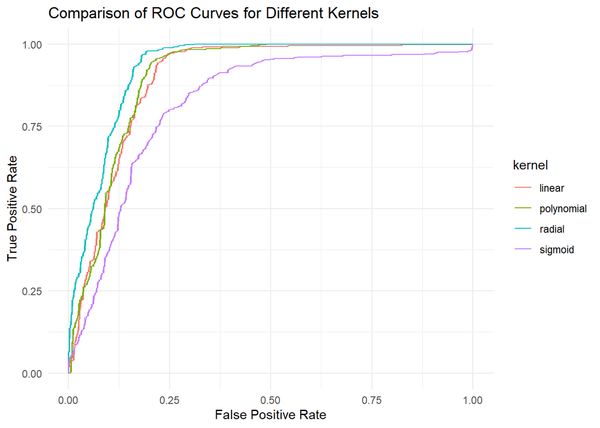

```r
# Plot ROC Curves for all kernels in one plot
ggplot(roc_data, aes(x = fp, y = tp, color = kernel)) +
  geom_line() +
  theme_minimal() +
  labs(title = "Comparison of ROC Curves for Different Kernels",
       x = "False Positive Rate",
       y = "True Positive Rate")
```

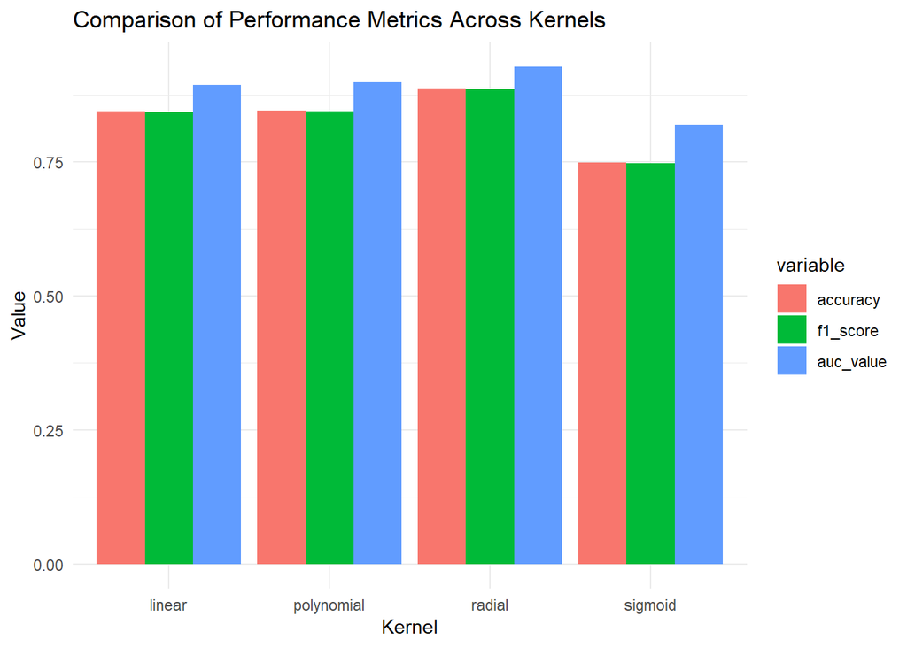

```r
# Performance Metrics Comparison
melted_results <- suppressWarnings(melt(results, id.vars = "kernel"))

ggplot(melted_results, aes(x = kernel, y = value, fill = variable)) +
  geom_bar(stat = "identity", position = position_dodge()) +
  theme_minimal() +
  labs(title = "Comparison of Performance Metrics Across Kernels",
       x = "Kernel", y = "Value")
```

SVM Results:

-Radial Kernel: Highest accuracy and AUC, indicating excellent overall performance and ability to distinguish between classes.

-Polynomial Kernel: Moderate performance, slightly behind the radial kernel.

-Sigmoid Kernel: Lowest performance, indicating it might not be the best fit for this particular dataset.